# HW 4-5

Group 7: Lara Elena Abdünnur, Emirhan Esen, Alp Çıtıroğlu

7/1/2021

## 1. Introduction

The aim of this project is to build a forcecasting model for the sale quantities of 9 different products of an online retailer, Trendyol. Each model is built by following certain steps. First, the seasonality of the sales are analyzed by decomposing the data on different levels. Second step is to fit an ARIMA model based on the findings. Third step is to analyze the possible regressors. Fourth and the final step is to build an ARIMAX model and compare the performance measures of the ARIMA and ARIMAX models on a test period of one week.

Before starting modeling, required data manipulations are done on the data set.Also, weekday and month info are added to the data set, since they may help on explaining the volume of sales.

## 2. Model of Bavy Wipes Sales

# 2.1 Visualisation of the Data

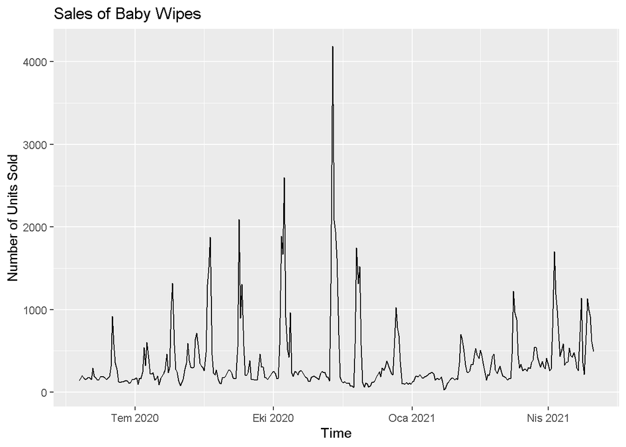

```
##
## #######################
## # KPSS Unit Root Test #
## #######################
##
## Test is of type: mu with 5 lags.
##
## Value of test-statistic is: 0.1762
##
## Critical value for a significance level of:
##                 10pct  5pct 2.5pct  1pct
## critical values 0.347 0.463  0.574 0.739
```

The KPSS test statistic shows that the series is already stationary.

# 2.2 Decomposition

# 2.2.a Daily Decompostion (Frequency=7)

There is no changing variance so we can use additive decompositon.

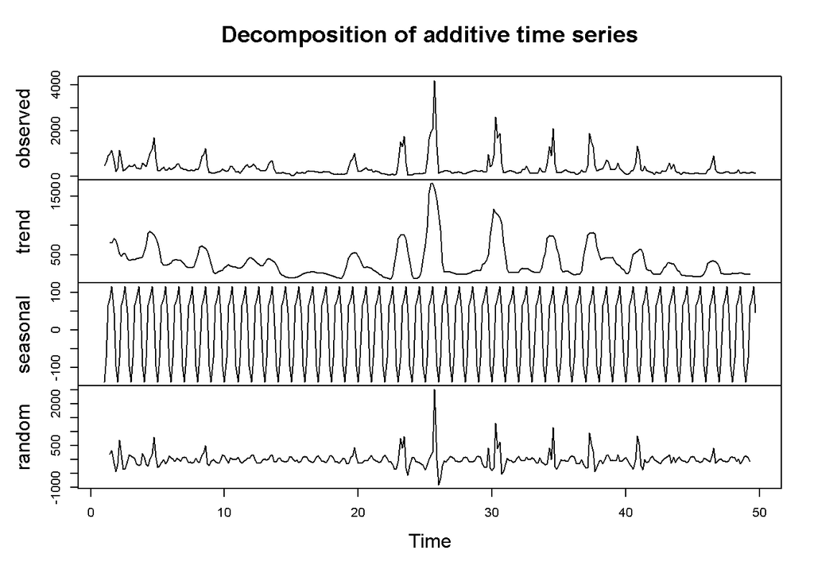

```
##
## #######################
## # KPSS Unit Root Test #
## #######################
##
## Test is of type: mu with 5 lags.
##
## Value of test-statistic is: 0.0074
##
## Critical value for a significance level of:
##                 10pct  5pct 2.5pct  1pct
## critical values 0.347 0.463  0.574 0.739
```

The random component is satisfying the zero mean assumption. Also the variance seems to be constant, however the outlier point during the Black Friday is detoriating this assumption.Kpss test shows that we achieved stationarity The seasonal component shows that the sales increase towards the middle of the week. There is no particular pattern on the trend component, but roughly it seems to be following a wave pattern.

# 2.2.b Decomposition at frequency=30

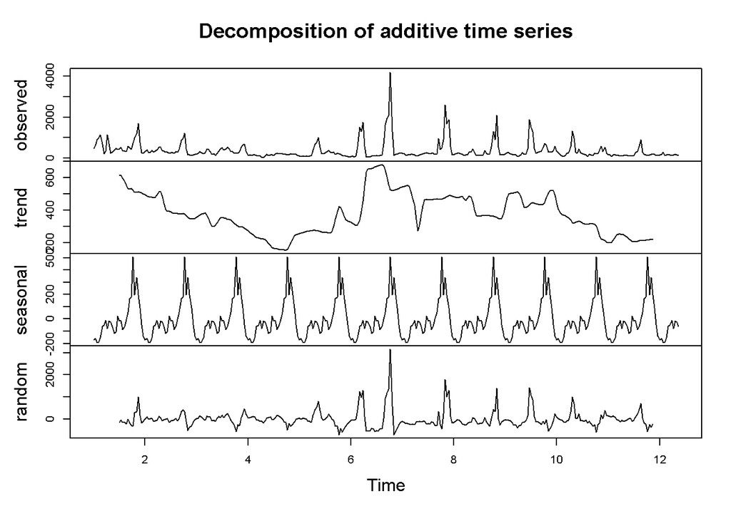

```
##
## #######################
## # KPSS Unit Root Test #
## #######################
##
## Test is of type: mu with 5 lags.
##
## Value of test-statistic is: 0.0102
##
## Critical value for a significance level of:
##                 10pct  5pct 2.5pct  1pct
## critical values 0.347 0.463  0.574 0.739
```

The random component is not satisfying the zero mean assumption and due to outlier points constant variance assumption doesn’t stictly satisfied. But, the kpss test shows that we achieved stationarity. The seasonal component shows that there is a peak happening towards the end of the 30 day period.The trend component doesn’t show a particular pattern.

We will continue with daily decomposition due to the better distribution of random component.

# 2.3 ARIMA Model

The sinusoidal pattern in the ACF plot shows that we can add an AR parameter. When we look at the PACF plot, we observe that significance of partial auto correlation is decreasing after lag 3. So, p=3 can be used.

There is a sinusoidal pattern in the PACF plot as well. After checking the ACF plot we can say that q=1 and q=4 are possible options.

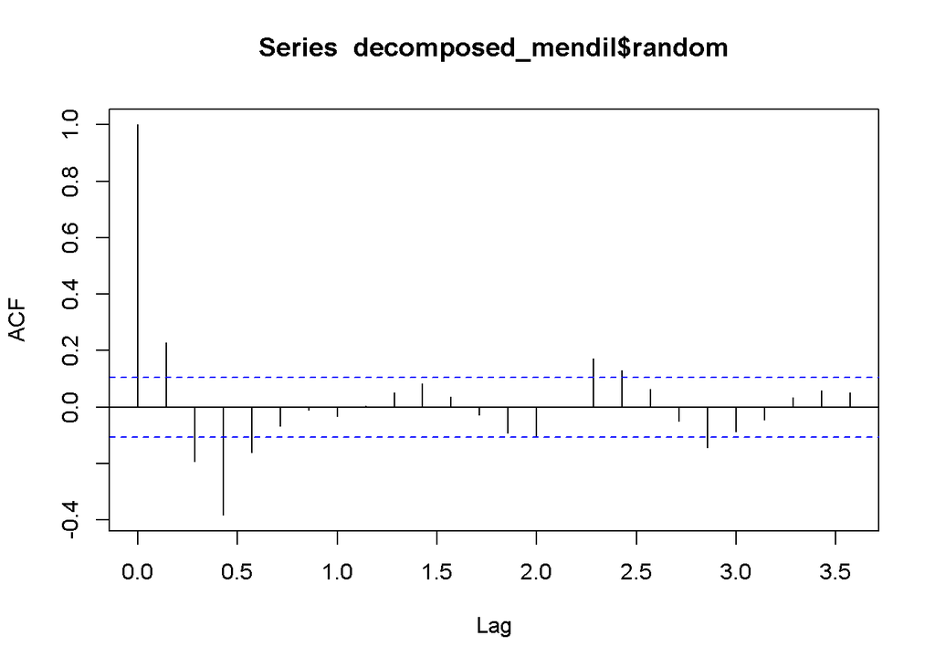

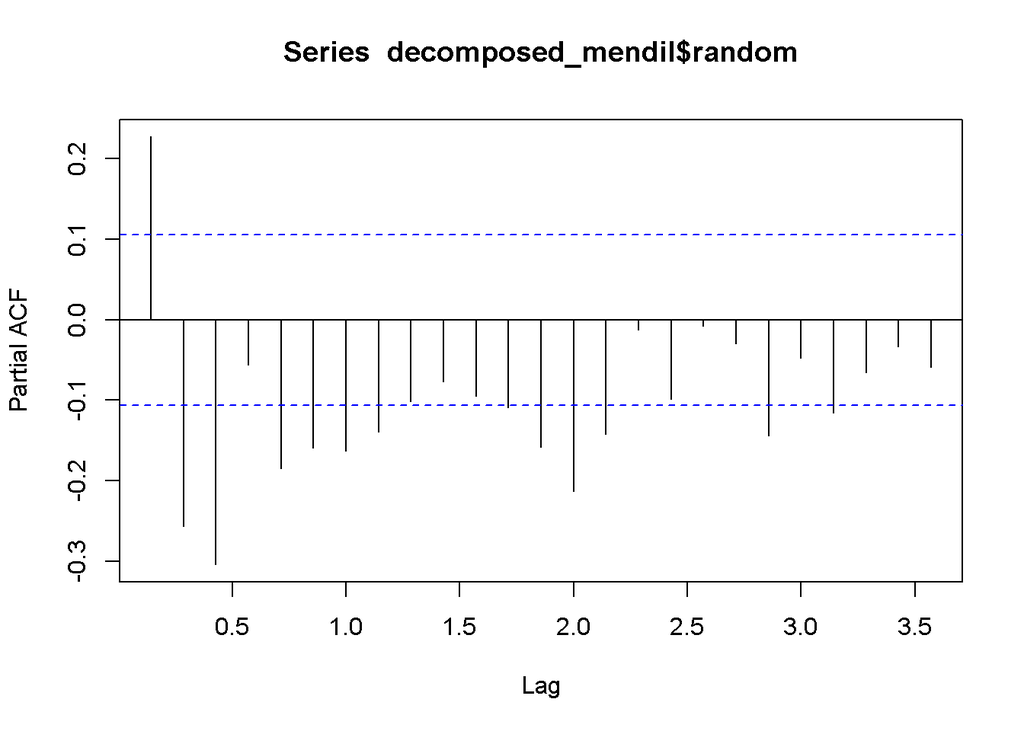

```
##      [,1]               [,2]
## [1,] "model 1"          "model 2"
## [2,] "4560.31698043059" "4525.21017783575"
```

The models provided a high AIC values. Model 2 is better than model 1 due to its lower AIC.

# 2.4 Regressor Analysis

```
##
## Call:
## lm(formula = sold_count ~ ., data = data_mendil)
##
## Residuals:
##     Min      1Q  Median      3Q     Max
## -456.45  -23.39    5.34   27.78  695.90
##
## Coefficients:
##                       Estimate Std. Error t value Pr(>|t|)
## (Intercept)          4.553e+03  6.184e+03   0.736 0.462084
## price               -2.666e+00  1.815e+00  -1.469 0.142923
## event_date          -2.370e-01  3.331e-01  -0.711 0.477399
## visit_count         -1.641e-02  1.194e-02  -1.374 0.170391
## favored_count        5.538e-02  1.030e-01   0.538 0.591150
## basket_count         2.935e-01  1.639e-02  17.908  < 2e-16 ***
## category_sold        7.123e-02  1.847e-02   3.857 0.000139 ***
## category_brand_sold -2.220e-02  9.768e-03  -2.272 0.023736 *
## category_visits      8.178e-02  1.106e-02   7.396 1.30e-12 ***
## ty_visits            6.533e-07  6.675e-07   0.979 0.328491
## category_basket      3.348e-05  1.778e-03   0.019 0.984986
## category_favored    -2.284e-02  2.901e-03  -7.871 5.81e-14 ***
## w_dayCum            -1.482e+01  1.844e+01  -0.804 0.422136
## w_dayÇar            -2.934e+01  1.916e+01  -1.531 0.126746
## w_dayPaz            -9.483e+00  1.833e+01  -0.517 0.605339
## w_dayPer            -1.619e+01  1.886e+01  -0.858 0.391320
## w_dayPzt            -4.052e+00  1.901e+01  -0.213 0.831312
## w_daySal            -1.274e+01  1.928e+01  -0.661 0.509362
## monthAra             6.332e+01  5.332e+01   1.187 0.235937
## monthEki             7.085e+00  3.139e+01   0.226 0.821586
## monthEyl             6.336e+00  2.627e+01   0.241 0.809530
## monthHaz             3.334e+01  3.237e+01   1.030 0.303883
## monthKas             1.642e+01  4.104e+01   0.400 0.689404
## monthMar             9.529e+01  6.455e+01   1.476 0.140873
## monthMay             2.141e+01  4.256e+01   0.503 0.615371
## monthNis             1.095e+02  7.094e+01   1.543 0.123780
## monthOca             5.128e+01  5.927e+01   0.865 0.387574
## monthŞub             5.692e+01  5.716e+01   0.996 0.320144
## monthTem             1.199e+01  2.517e+01   0.476 0.634335
## ---
## Signif. codes:  0 '***' 0.001 '**' 0.01 '*' 0.05 '.' 0.1 ' ' 1
##
## Residual standard error: 89.47 on 313 degrees of freedom
## Multiple R-squared:  0.9604, Adjusted R-squared:  0.9569
## F-statistic: 271.3 on 28 and 313 DF,  p-value: < 2.2e-16
```

Due to their high significance candidate regressors are; basket_count, category_sold, category_visits and category_favored.

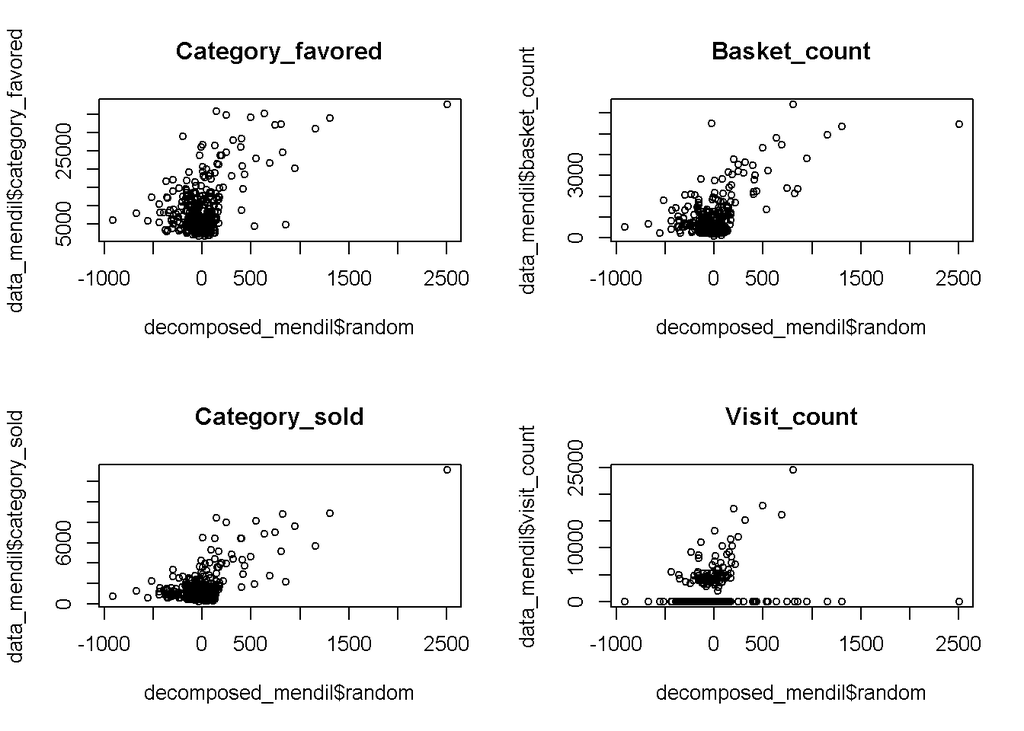

We decided on using basket_count and category_favored after the visual inspection.

# 2.5 ARIMAX Model

Now we will add the regression matrix to our models and observe if there is any improvement.

```
##      [,1]               [,2]               [,3]
## [1,] "model 1"          "model 2"          "auto.arima"
## [2,] "4518.58873377635" "4517.87112537415" "4499.30141499037"
```

The models are slightly improved and the auto.arima function provided a better result. The model found by auto.arima function have (1,1,1) as parameter values.

# 2.6 Performance of the Models

```
##    n     mean       sd        CV     FBias      MAPE     RMSE      MAD
## 1: 7 183.4286 49.05051 0.2674093 0.4068333 0.5177782 103.7165 89.34991
##         MADP     WMAPE
## 1: 0.4871101 0.4871101
```

```
##    n     mean       sd        CV     FBias      MAPE     RMSE      MAD
## 1: 7 183.4286 49.05051 0.2674093 0.4300238 0.4601107 94.54271 80.80355
##         MADP     WMAPE
## 1: 0.4405178 0.4405178
```

```
##    n     mean       sd        CV      FBias     MAPE     RMSE      MAD
## 1: 7 185.7143 49.66459 0.2674247 0.04230242 0.599509 133.2886 110.2421
##         MADP     WMAPE
## 1: 0.5936115 0.5936115
```

The model 2 ,which have parameters (3,0,4), seems to be a better model due to its lower RMSE and MAPE value.

## 3. Model of Tight Sales

# 3.1 Visualisation of the Data

Sales of tights doesn’t seem to have any seasonal pattern. Probably the small peaks in the sales are during promotion times. Again we are observing a very high peak during the Black Friday, which can be categorized as an outlier point.

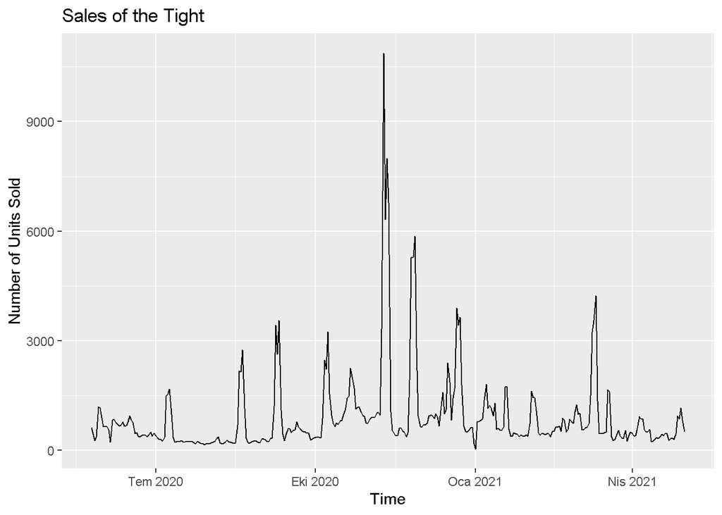

The KPSS test shows that the series is not stationary

```
##
## #######################
## # KPSS Unit Root Test #
## #######################
##
## Test is of type: mu with 5 lags.
##
## Value of test-statistic is: 0.3755
##
## Critical value for a significance level of:
##                 10pct  5pct 2.5pct  1pct
## critical values 0.347 0.463  0.574 0.739
```

# 3.2 Decomposition

The sales data is available for only 13 months. That’s why the number of periods is not sufficient to obtain weekly and monthly seasonality by using decompose() function. So, the decompose function is only working on the daily level. So, we decided to try decompose with different frequency values, which are 7 and 30.

# 3.2.a Daily Decompostion (Frequency=7)

Multiplicative decomposition is a better option due to the increasing variance, especially during the fall.

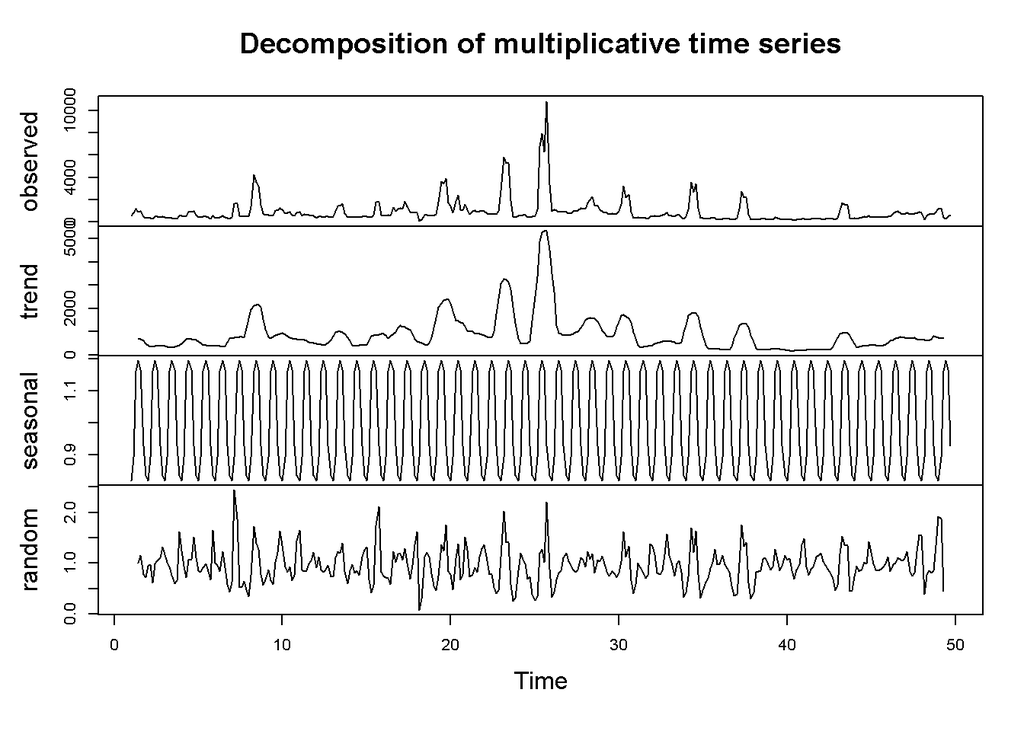

```
##
## #######################
## # KPSS Unit Root Test #
## #######################
##
## Test is of type: mu with 5 lags.
##
## Value of test-statistic is: 0.074
##
## Critical value for a significance level of:
##                 10pct  5pct 2.5pct  1pct
## critical values 0.347 0.463  0.574 0.739
```

We can see that we achieved stationarity depending on the KPSS test. Also the random component is following the mean zero and constant variance assumptions. The seasonal component shows that the sales tend to increase towards the middle of the weak, and decrease towards the end of the week. There is no specific trend, but we can observe the effect of Black Friday on the trend component.

We can continue with daily decomposition since random component satisfies the assumptions and stationarity is achieved.

# 3.2.Decompostion with frequency=30

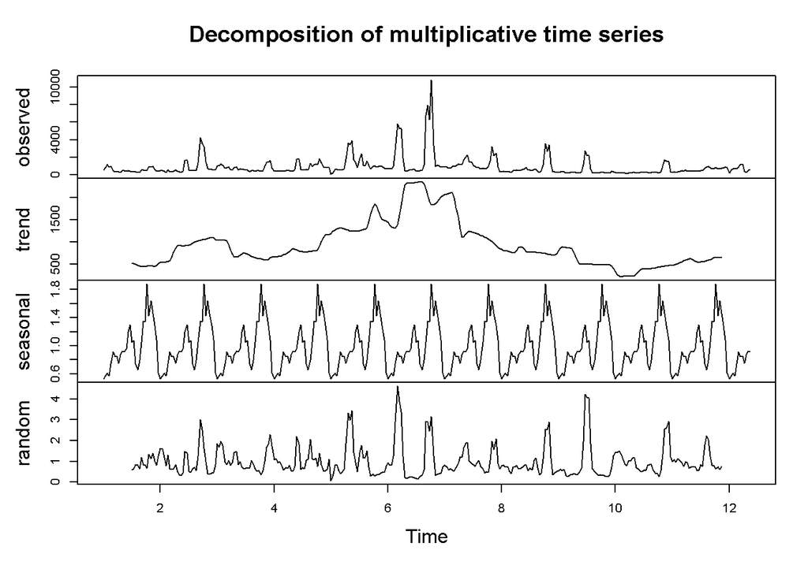

```
##
## #######################
## # KPSS Unit Root Test #
## #######################
##
## Test is of type: mu with 5 lags.
##
## Value of test-statistic is: 0.0199
##
## Critical value for a significance level of:
##                 10pct  5pct 2.5pct  1pct
## critical values 0.347 0.463  0.574 0.739
```

Since the daily decomposition is providing a better random component we will continue with it.

# 3.3 ARIMA Model

First we need to check ACF and PACF to decide on which parameter to use.

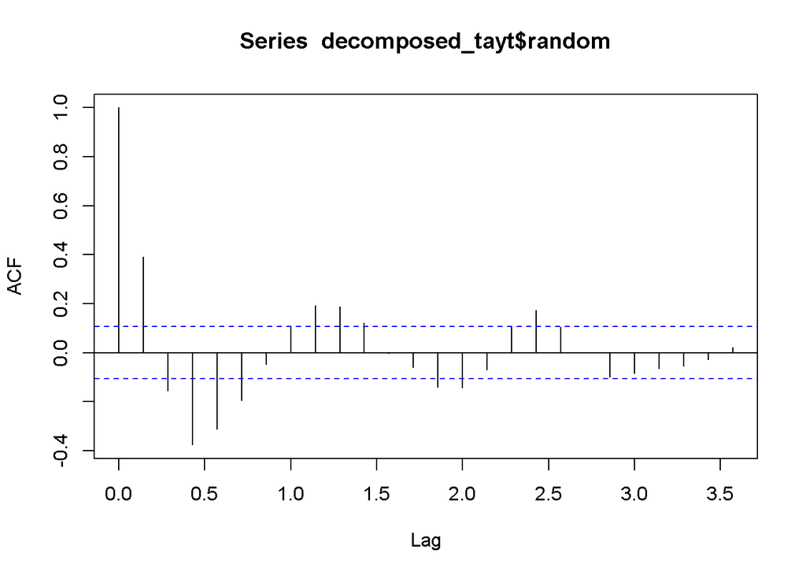

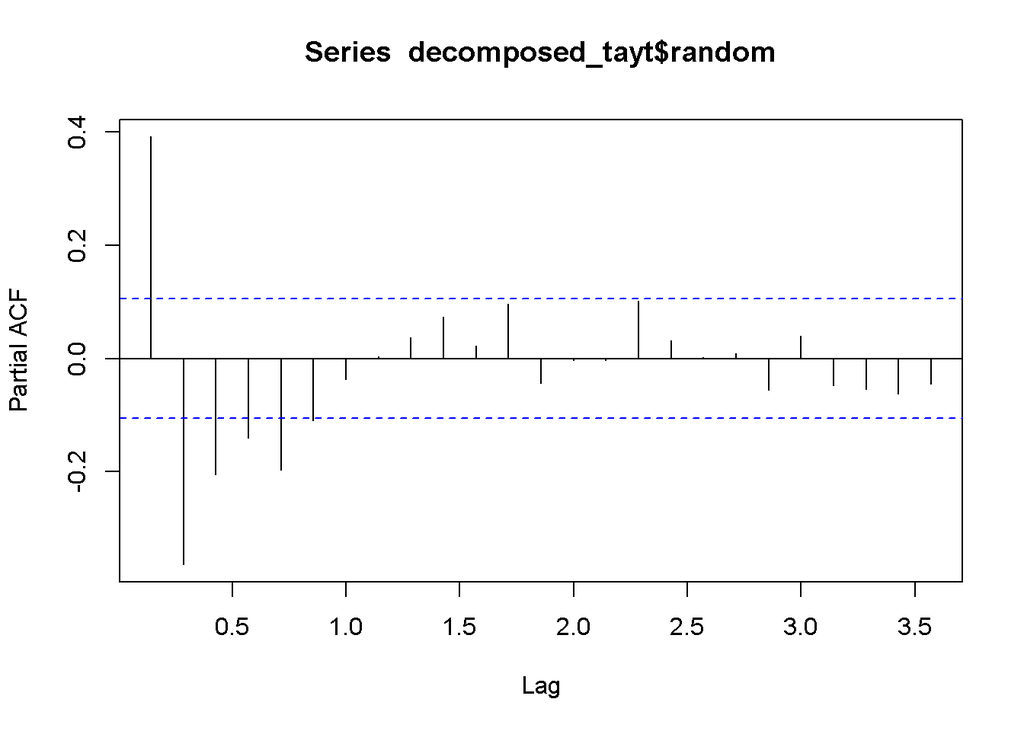

We can add AR parameter, since ACF plot is following a sinusoidal pattern. After lag 2 signifigance of partial autocorrelation is decreasing so p=2 can be considered.

We can add MA parameter as well, since PACF plot is following a sinusoidal pattern. Depending on the ACF plot, we can try several values as MA parameter such as q=1 and q=2.

```
##      [,1]               [,2]
## [1,] "model 1"          "model 2"
## [2,] "115.167258661379" "117.144775367153"
```

We tried the models with parameters (2,0,1) and (2,0,2). Model 1 provided a better result with a lower AIC.

# 3.4 Regressor Analysis

In order to find the significance of the input attributes on explaining the sold_count, we built a linear regression model.Then we plotted the ones with high significance values with the random component. We chose the ones that would work well on explaining the behavior of the random component. Note that this method is going to be used for every product.

```
##
## Call:
## lm(formula = sold_count ~ ., data = data_tayt)
##
## Residuals:
##      Min       1Q   Median       3Q      Max
## -1248.25   -67.87     1.20    76.06  1106.52
##
## Coefficients:
##                       Estimate Std. Error t value Pr(>|t|)
## (Intercept)          3.441e+04  1.505e+04   2.286  0.02293 *
## price               -7.861e-01  5.918e+00  -0.133  0.89441
## event_date          -1.852e+00  8.193e-01  -2.260  0.02450 *
## visit_count         -1.199e-02  2.128e-03  -5.636 3.89e-08 ***
## favored_count       -3.119e-02  2.198e-02  -1.419  0.15686
## basket_count         1.284e-01  9.058e-03  14.176  < 2e-16 ***
## category_sold        3.200e-01  2.851e-02  11.223  < 2e-16 ***
## category_brand_sold -2.047e-04  2.259e-03  -0.091  0.92787
## category_visits      9.927e-02  1.042e-02   9.526  < 2e-16 ***
## ty_visits           -3.942e-07  2.351e-06  -0.168  0.86693
## category_basket      9.640e-04  3.593e-04   2.683  0.00769 **
## category_favored    -2.835e-02  2.499e-03 -11.344  < 2e-16 ***
## w_dayCum            -3.450e+01  4.045e+01  -0.853  0.39435
## w_dayÇar            -4.151e+01  4.045e+01  -1.026  0.30559
## w_dayPaz            -4.695e+00  3.999e+01  -0.117  0.90662
## w_dayPer            -2.416e+01  4.090e+01  -0.591  0.55514
## w_dayPzt             5.194e+01  4.034e+01   1.288  0.19881
## w_daySal             3.245e+01  4.072e+01   0.797  0.42610
## monthAra             1.524e+02  1.211e+02   1.259  0.20903
## monthEki             1.011e+02  7.286e+01   1.387  0.16635
## monthEyl             1.112e+02  5.794e+01   1.919  0.05594 .
## monthHaz            -1.703e+02  7.128e+01  -2.390  0.01745 *
## monthKas            -3.638e+01  9.199e+01  -0.395  0.69275
## monthMar             2.230e+02  1.365e+02   1.634  0.10329
## monthMay            -1.396e+02  9.563e+01  -1.460  0.14525
## monthNis             1.605e+02  1.487e+02   1.080  0.28118
## monthOca             3.058e+02  1.357e+02   2.253  0.02495 *
## monthŞub            -2.136e+01  1.251e+02  -0.171  0.86454
## monthTem            -1.040e+02  5.542e+01  -1.876  0.06159 .
## ---
## Signif. codes:  0 '***' 0.001 '**' 0.01 '*' 0.05 '.' 0.1 ' ' 1
##
## Residual standard error: 194.4 on 313 degrees of freedom
## Multiple R-squared:  0.9731, Adjusted R-squared:  0.9707
## F-statistic: 405.2 on 28 and 313 DF,  p-value: < 2.2e-16
```

The most significant input attributes can be seen as visit_count,basket_count,category_sold,category_visits and category_favored. Since visit_count and category_visits are correlated using only one of them would be a better option.

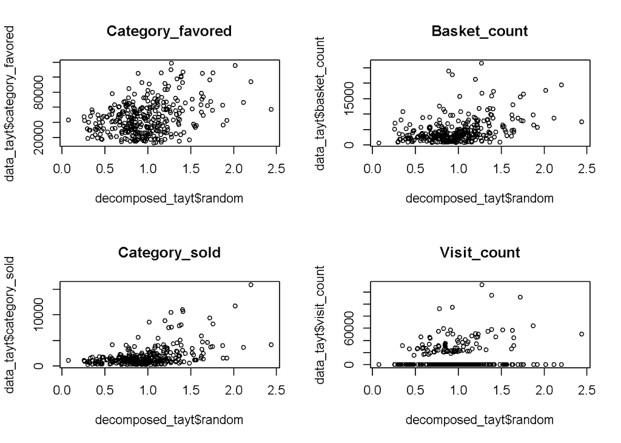

We chose to use category_favored and basket_count as regressors since they have provide a better distribution with the random component, which is close to the x=y line.

# 3.5 ARIMAX Model

Now, we are going to add the regression matrix to the ARIMA models that we found before, and see if there is any improvement.

```
##      [,1]               [,2]               [,3]
## [1,] "model 1"          "model 2"          "auto.arima"
## [2,] "99.4371862930797" "100.819757387839" "175.174968528701"
```

As we can see both of the models are improved with lower AIC values. Still model 1 is providing a better result. Auto.arima function didn’t provide a better result.

# 3.6 Performance of the Models

Now we will evaluate the models over a one week test period.

```
##    n     mean       sd      CV      FBias      MAPE     RMSE      MAD      MADP
## 1: 7 792.8571 302.6177 0.38168 0.04881752 0.3681687 292.1271 240.1632 0.3029085
##        WMAPE
## 1: 0.3029085
```

```
##    n     mean       sd      CV      FBias      MAPE     RMSE      MAD      MADP
## 1: 7 792.8571 302.6177 0.38168 0.04581846 0.3721184 294.3708 241.5317 0.3046346
##        WMAPE
## 1: 0.3046346
```

```
##    n     mean       sd       CV      FBias     MAPE     RMSE      MAD      MADP
## 1: 7 633.4286 217.2286 0.342941 -0.2968787 0.580786 325.1748 266.6277 0.4209277
##        WMAPE
## 1: 0.4209277
```

## 4. Model of Bikini Top 1 Sales

# 4.1 Visualisation of the Data

The plot shows that the bikini top 1 didn’t have any sales till February 2021. This might due to a mistake in the data or the sale of the product haven’t started till that date. The sales have very high peaks in March and May and the rest of the months the sales approach to zero.

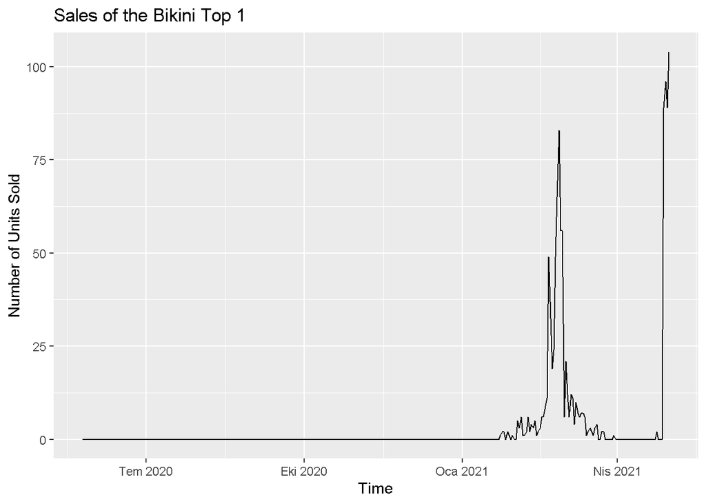

```
##
## #######################
## # KPSS Unit Root Test #
## #######################
##
## Test is of type: mu with 5 lags.
##
## Value of test-statistic is: 0.907
##
## Critical value for a significance level of:
##                 10pct  5pct 2.5pct  1pct
## critical values 0.347 0.463  0.574 0.739
```

# 4.2 Decomposition

# 4.2.a Daily Decompostion (Frequency=7)

Additive decopmposition is a better option since variance is not increasing.

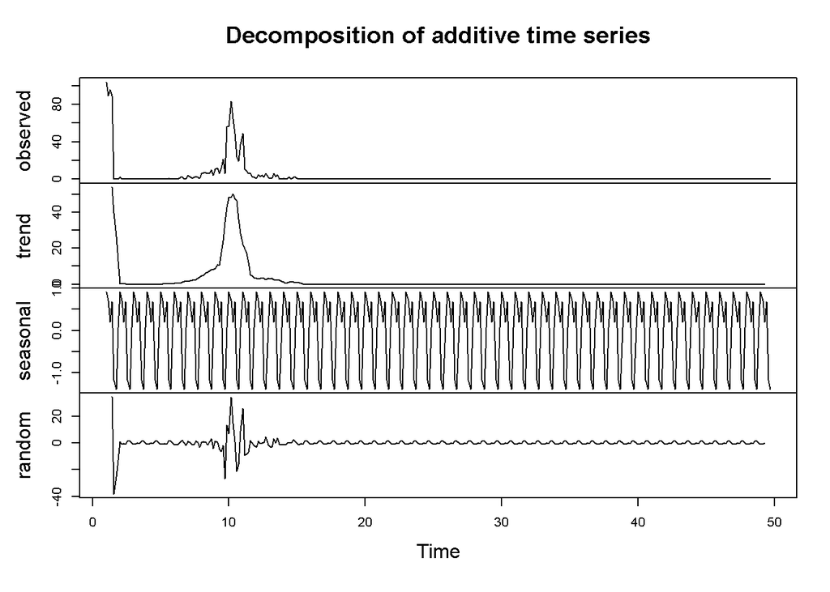

```
##
## #######################
## # KPSS Unit Root Test #
## #######################
##
## Test is of type: mu with 5 lags.
##
## Value of test-statistic is: 0.1342
##
## Critical value for a significance level of:
##                 10pct  5pct 2.5pct  1pct
## critical values 0.347 0.463  0.574 0.739
```

The random component is satisfying the zero mean assumption. The variance is nearly constant but some outlier points are creating small jumps on the data. The trend component is showing the increasing sales during the March and for the rest of the months it’s zero. The seasonality component shows that there is an increase in sales towards the beginning of the week. The kpss test shows that we achieved stationarity.

# 4.2.b Decompostion at Frequency=30

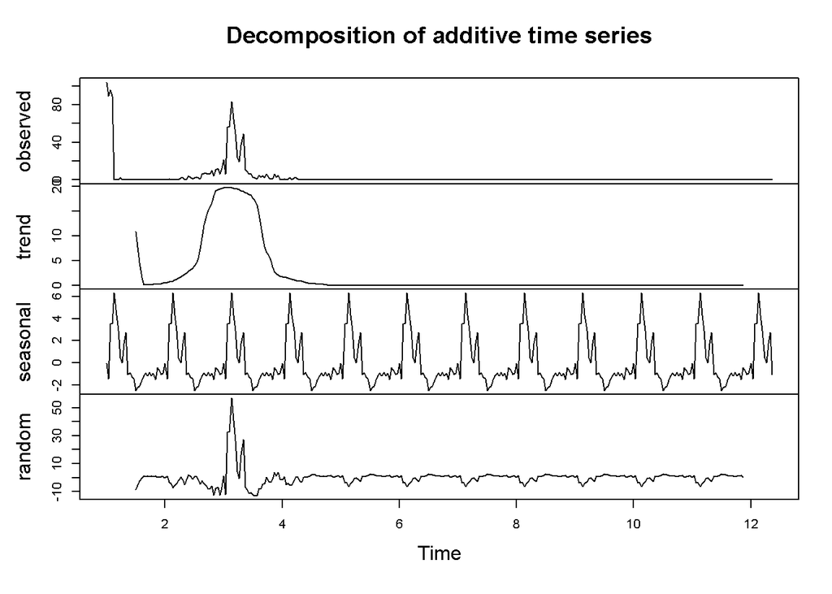

```
##
## #######################
## # KPSS Unit Root Test #
## #######################
##
## Test is of type: mu with 5 lags.
##
## Value of test-statistic is: 0.0199
##
## Critical value for a significance level of:
##                 10pct  5pct 2.5pct  1pct
## critical values 0.347 0.463  0.574 0.739
```

Due to the outlier points the random component has a high peak which deteriorates the constant variance assumption. We can say that it’s satisfying the zero mean assumption. Also the kpss test shows that it is stationary. Seasonality component shows that sales tend to increase towards the end of the 30 day period. Trend component is showing the increase during the March and May and it’s zero in the rest of the months.

Daily decomposition is providing a better result, so we will continue with it.

# 4.3 ARIMA Model

ACF plot has a sinusoidal pattern and significance of PACF is decreasing after lag 3 that’s why p=3 is a possible option. PACF plot is also showing a sinusoidal pattern and depending on the ACF plot we can try q=4 and q=1.

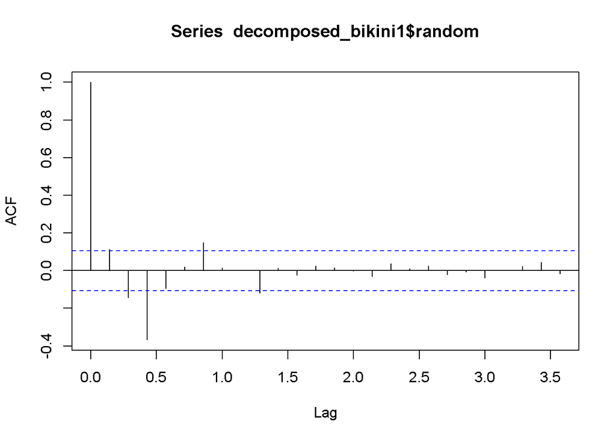

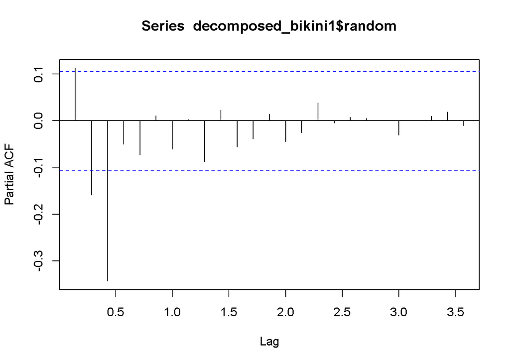

```
##      [,1]               [,2]
## [1,] "model 1"          "model 2"
## [2,] "1900.93122372419" "1927.67968265158"
```

The model 1 ,which have parameters (3,0,4), seems to be a better model due to its lower AIC value.

# 4.4 Regressor Analysis

```
##
## Call:
## lm(formula = sold_count ~ ., data = data_bikini1)
##
## Residuals:
##     Min      1Q  Median      3Q     Max
## -11.871  -1.958   0.000   2.529   7.728
##
## Coefficients: (1 not defined because of singularities)
##                       Estimate Std. Error t value Pr(>|t|)
## (Intercept)          3.321e+02  2.606e+03   0.127 0.899236
## price                       NA         NA      NA       NA
## event_date          -1.784e-02  1.394e-01  -0.128 0.898795
## visit_count         -6.980e-03  1.586e-03  -4.401 7.79e-05 ***
## favored_count        3.849e-02  9.171e-03   4.197 0.000146 ***
## basket_count         2.172e-01  2.523e-02   8.609 1.20e-10 ***
## category_sold       -6.884e-03  1.004e-02  -0.686 0.496856
## category_brand_sold -1.903e-04  2.632e-04  -0.723 0.473797
## category_visits      1.812e-02  8.858e-03   2.046 0.047388 *
## ty_visits            3.130e-08  4.304e-08   0.727 0.471256
## category_basket      1.547e-05  5.316e-05   0.291 0.772554
## category_favored    -1.560e-03  1.018e-03  -1.533 0.133063
## w_dayCum             5.704e-01  2.657e+00   0.215 0.831100
## w_dayÇar             1.206e+00  2.379e+00   0.507 0.614918
## w_dayPaz             3.832e+00  2.616e+00   1.465 0.150757
## w_dayPer            -8.140e-01  2.634e+00  -0.309 0.758864
## w_dayPzt             2.178e+00  2.736e+00   0.796 0.430707
## w_daySal            -1.079e+00  2.523e+00  -0.428 0.671119
## monthMay             2.768e+00  1.386e+01   0.200 0.842675
## monthNis             1.161e+01  9.525e+00   1.219 0.229876
## monthOca            -2.769e+00  6.923e+00  -0.400 0.691356
## monthŞub            -7.770e+00  4.513e+00  -1.722 0.092849 .
## ---
## Signif. codes:  0 '***' 0.001 '**' 0.01 '*' 0.05 '.' 0.1 ' ' 1
##
## Residual standard error: 4.745 on 40 degrees of freedom
##   (281 observations deleted due to missingness)
## Multiple R-squared:  0.9797, Adjusted R-squared:  0.9696
## F-statistic: 96.71 on 20 and 40 DF,  p-value: < 2.2e-16
```

The most significant input attributes can be seen as visit_count,basket_count and favored_count.Now we will plot these attributes with random component to visualize their relation.

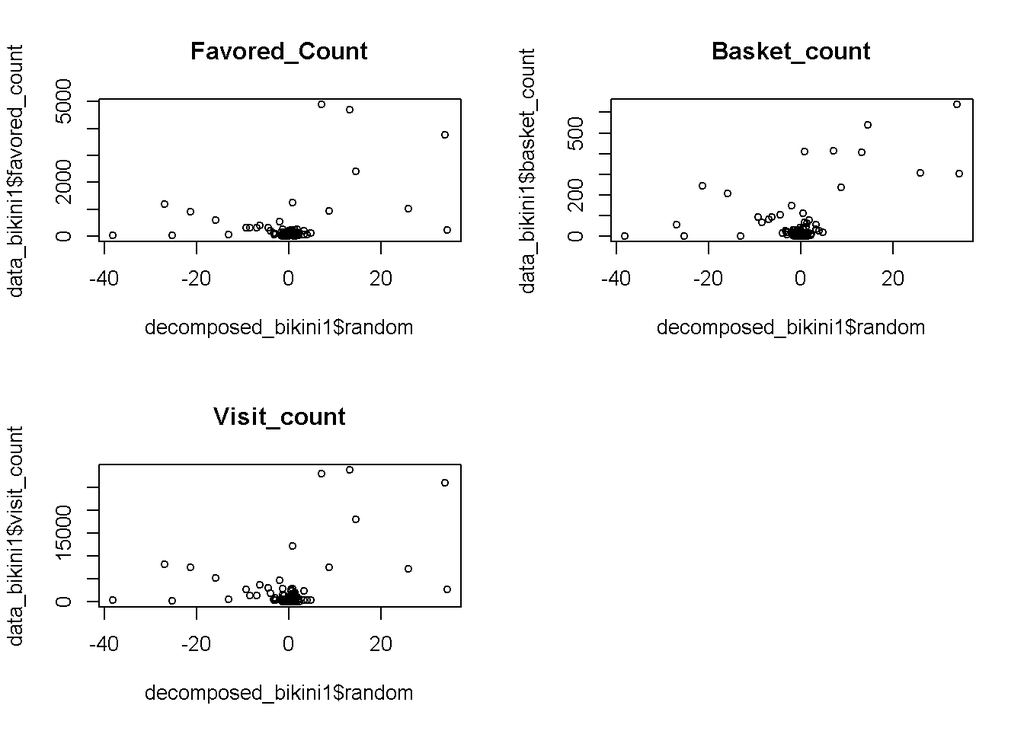

The attributes are not really distributed along the x=y line, however basket_count is providing a better result and it can be used as a regressor.

# 4.5 ARIMAX Model

```
##      [,1]               [,2]               [,3]
## [1,] "model 1"          "model 2"          "auto.arima"
## [2,] "1886.04314099755" "1889.82913998634" "1655.43098553736"
```

We can see that the models are improved as they have lower AIC values. Auto.arima function found a SARIMAX model with parameters (5,1,1)(2,0,0)[7]. This resulted in a much better model compoared to others.

# 4.6 Performance of the Models

Now we will evaluate the models over a one week test period.

```
##    n mean sd  CV FBias MAPE      RMSE       MAD MADP WMAPE
## 1: 7    0  0 NaN   Inf  Inf 0.8956691 0.7182562  Inf   Inf
```

```
##    n mean sd  CV FBias MAPE      RMSE       MAD MADP WMAPE
## 1: 7    0  0 NaN   Inf  Inf 0.8750826 0.7089788  Inf   Inf
```

```
##    n mean sd  CV FBias MAPE      RMSE       MAD MADP WMAPE
## 1: 7    0  0 NaN  -Inf  Inf 0.9303393 0.7170653  Inf   Inf
```

## 5. Model of Bikini Top 2 Sales

# 5.1 Visualisation of the Data

The plot shows that the bikini sales start to increase starting from spring time and decrease towards the fall. During fall and winter there are approximately no sales.

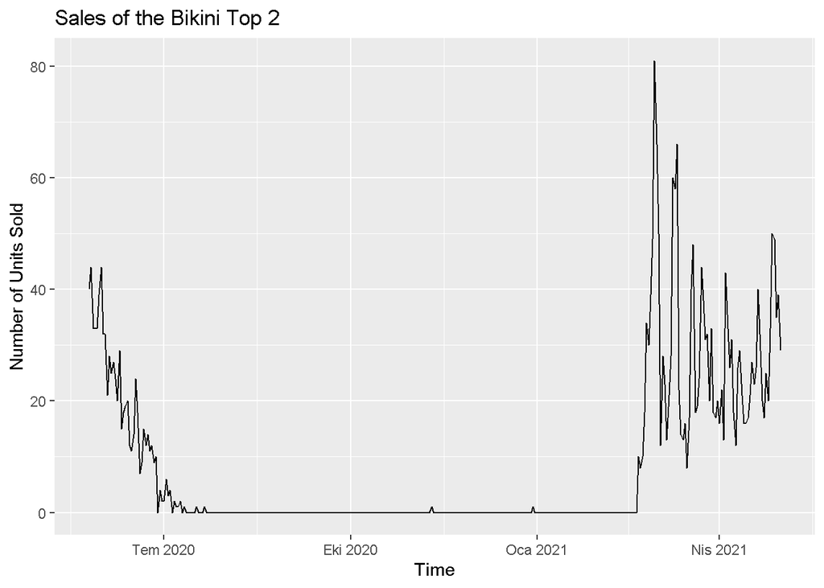

```
##
## #######################
## # KPSS Unit Root Test #
## #######################
##
## Test is of type: mu with 5 lags.
##
## Value of test-statistic is: 1.4747
##
## Critical value for a significance level of:
##                 10pct  5pct 2.5pct  1pct
## critical values 0.347 0.463  0.574 0.739
```

The KPSS test shows the series is not stationarity.

# 5.2 Decomposition

# 5.2.a Daily Decompostion

Additive decomposition is a better option since there are many zeros in the data multiplicative decomposition won’t provide a great result.

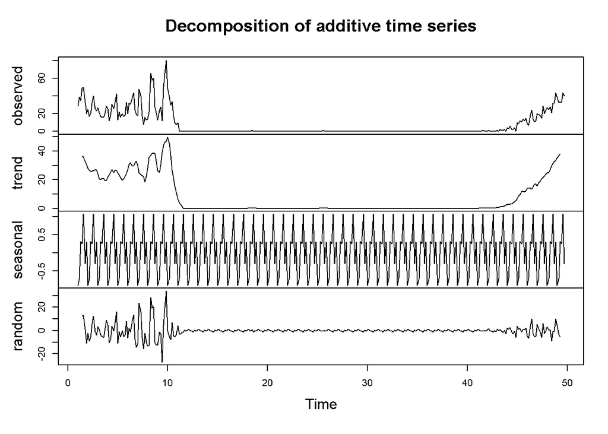

```
##
## #######################
## # KPSS Unit Root Test #
## #######################
##
## Test is of type: mu with 5 lags.
##
## Value of test-statistic is: 0.014
##
## Critical value for a significance level of:
##                 10pct  5pct 2.5pct  1pct
## critical values 0.347 0.463  0.574 0.739
```

The random component is satisfing the zero mean assumption but failing to satisfy the constant variance assumption since the distribution of sales are nearly zero during the fall and winter and very high during the spring and summer. Also the trend is explaining this behavior. Seasonal component shows that the sales increase towards the middle of the weak. The kpss test shows that we achieved stationarity

# 5.2.b Decompostion at Frequency=30

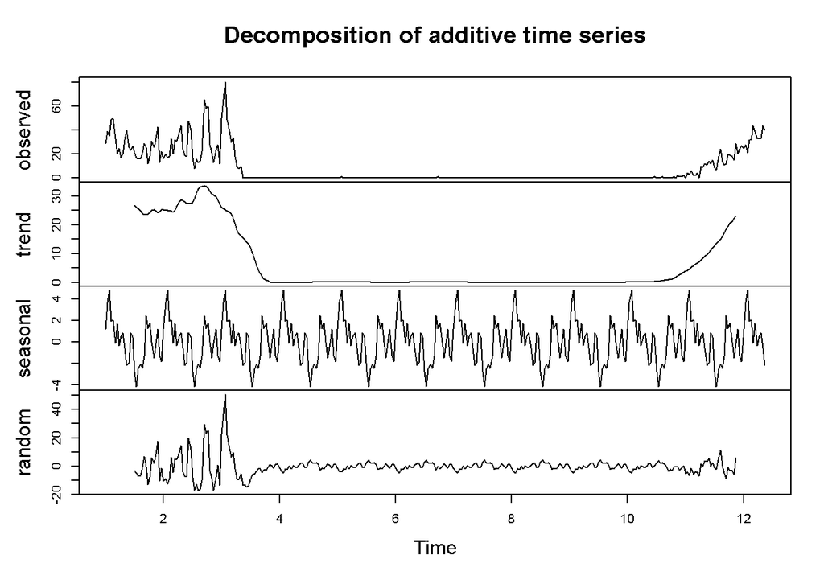

```
##
## #######################
## # KPSS Unit Root Test #
## #######################
##
## Test is of type: mu with 5 lags.
##
## Value of test-statistic is: 0.0206
##
## Critical value for a significance level of:
##                 10pct  5pct 2.5pct  1pct
## critical values 0.347 0.463  0.574 0.739
```

We will continue with daily decomposition since the random component is satisfying the assumptions better than the decomposition with frequency=30.

# 5.3 ARIMA Model

The sinusoidal pattern of ACF plot shows that we can use an AR parameter and PACF plot shows that we can try p=1. PACF plot also has a sinusoidal pattern, and depending on the ACF we can try q=3 and q=4.

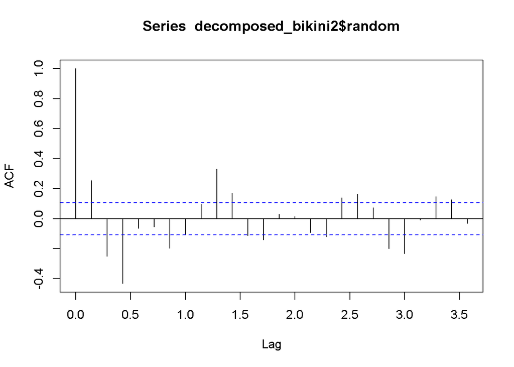

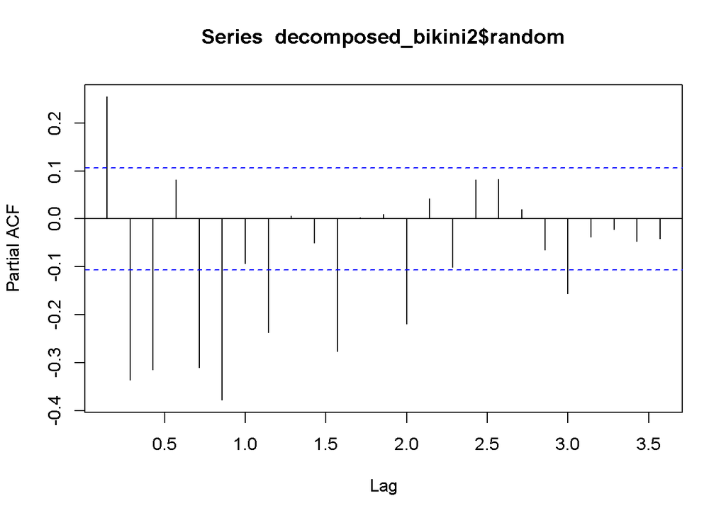

```
##      [,1]               [,2]
## [1,] "model 1"          "model 2"
## [2,] "1860.74669765977" "1840.10097803818"
```

Model 2, which has parameters (1,0,4) is better than model 1 due to its lower AIC value.

# 5.4 Regressor Analysis

```
##
## Call:
## lm(formula = sold_count ~ ., data = data_bikini2)
##
## Residuals:
##      Min       1Q   Median       3Q      Max
## -14.2579  -3.2122  -0.3426   3.1608  13.9726
##
## Coefficients:
##                       Estimate Std. Error t value Pr(>|t|)
## (Intercept)          1.153e+03  6.122e+02   1.883  0.06274 .
## price               -4.160e-01  3.534e-01  -1.177  0.24210
## event_date          -6.053e-02  3.299e-02  -1.835  0.06963 .
## visit_count          3.027e-03  2.810e-03   1.077  0.28416
## favored_count       -2.234e-02  1.515e-02  -1.475  0.14355
## basket_count         1.661e-01  1.930e-02   8.604 1.58e-13 ***
## category_sold        3.476e-03  1.309e-03   2.656  0.00928 **
## category_brand_sold  2.968e-04  2.495e-04   1.189  0.23723
## category_visits      8.674e-03  1.808e-03   4.798 5.94e-06 ***
## ty_visits            1.272e-07  5.012e-08   2.537  0.01280 *
## category_basket     -4.694e-05  3.859e-05  -1.216  0.22683
## category_favored    -2.144e-03  4.200e-04  -5.105 1.69e-06 ***
## w_dayCum             1.750e+00  1.978e+00   0.884  0.37871
## w_dayÇar            -1.757e-01  2.033e+00  -0.086  0.93131
## w_dayPaz            -1.011e-01  2.065e+00  -0.049  0.96103
## w_dayPer            -2.316e+00  2.139e+00  -1.083  0.28169
## w_dayPzt             2.229e-01  1.990e+00   0.112  0.91107
## w_daySal             1.081e+00  2.086e+00   0.518  0.60558
## monthHaz            -9.283e+00  8.459e+00  -1.097  0.27520
## monthKas            -7.308e+00  8.334e+00  -0.877  0.38281
## monthMar            -5.260e+00  6.881e+00  -0.764  0.44655
## monthMay            -4.871e+00  8.247e+00  -0.591  0.55618
## monthNis            -4.182e+00  6.713e+00  -0.623  0.53481
## monthŞub            -3.149e+00  7.619e+00  -0.413  0.68031
## monthTem            -7.643e+00  8.933e+00  -0.856  0.39441
## ---
## Signif. codes:  0 '***' 0.001 '**' 0.01 '*' 0.05 '.' 0.1 ' ' 1
##
## Residual standard error: 5.569 on 95 degrees of freedom
##   (222 observations deleted due to missingness)
## Multiple R-squared:  0.897,  Adjusted R-squared:  0.871
## F-statistic: 34.47 on 24 and 95 DF,  p-value: < 2.2e-16
```

The most significant input attributes can be seen as category_visits,basket_count and category_favored.Now we will plot these attributes with random component to visualize their relation.

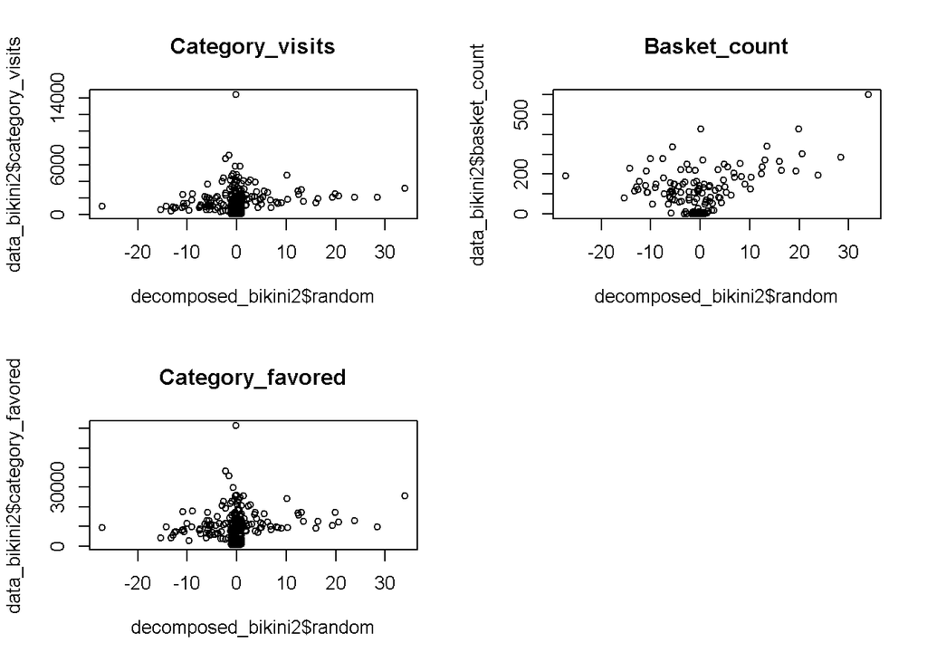

```
##      [,1]               [,2]               [,3]
## [1,] "model 1"          "model 2"          "auto.arima"
## [2,] "1862.11304435327" "1840.32376922434" "1869.12936334997"
```

We can see that the models are not improved as they don’t have any change in the AIC values. Auto.arima function found a SARIMAX model with parameters (3,1,4)(2,0,0)[7]. This model’s AIC value is higher so it’s not a better model.

# 5.6 Performance of the Models

```
##    n     mean       sd        CV       FBias       MAPE     RMSE      MAD
## 1: 7 33.42857 7.091242 0.2121312 -0.03015784 0.09854987 3.437614 2.839463
##          MADP      WMAPE
## 1: 0.08494121 0.08494121
```

```
##    n     mean       sd        CV     FBias      MAPE   RMSE      MAD       MADP
## 1: 7 33.42857 7.091242 0.2121312 -0.065553 0.1059776 3.6403 2.937807 0.08788312
##         WMAPE
## 1: 0.08788312
```

```
##    n     mean       sd        CV      FBias      MAPE     RMSE      MAD
## 1: 7 29.85714 7.335498 0.2456865 -0.1719859 0.2816097 9.551094 7.307867
##         MADP     WMAPE
## 1: 0.2447611 0.2447611
```

The model 1 ,which have parameters (1,0,3), seems to be a better model due to its lower RMSE value.

## 6. Model of Tooth Brush Sales

# 6.1 Visualisation of the Data

We can say that toothbrush has a frequent demand.There is an increasing trend in the sales, and there are some peaks observed, which probably corresponds to promotion times. These peaks may result in outlier points.

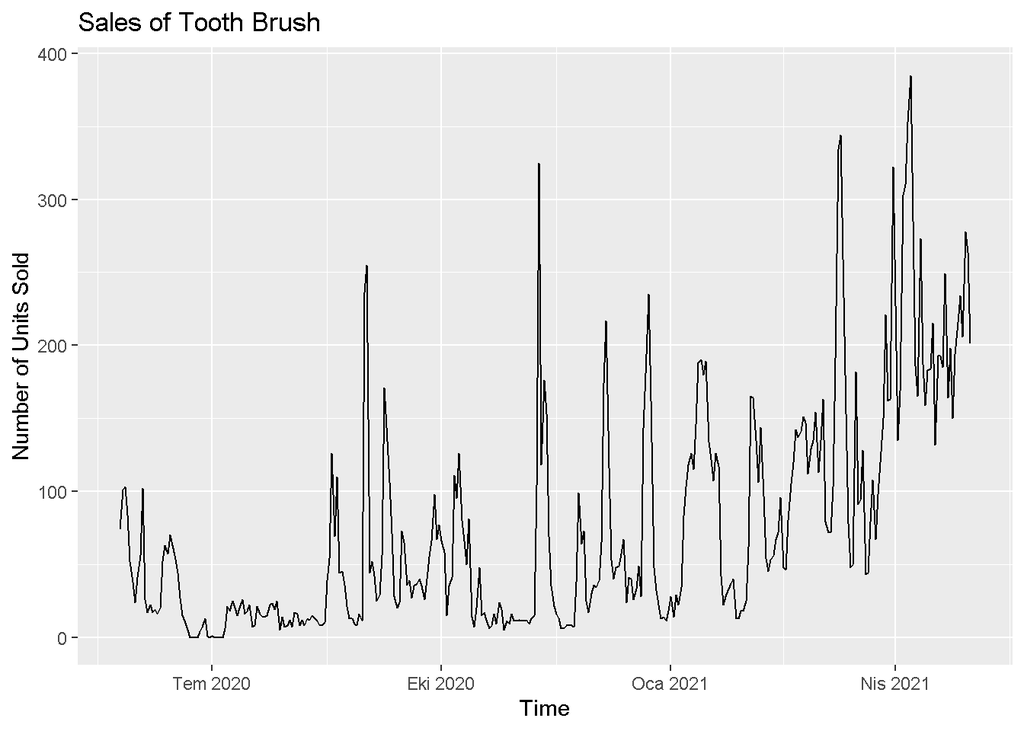

```
##
## #######################
## # KPSS Unit Root Test #
## #######################
##
## Test is of type: mu with 5 lags.
##
## Value of test-statistic is: 3.0682
##
## Critical value for a significance level of:
##                 10pct  5pct 2.5pct  1pct
## critical values 0.347 0.463  0.574 0.739
```

The high value of KPSS test shows that the series is not stationary.

# 6.2 Decomposition

# 6.2.a Daily Decompostion (Frequency=7)

Additive decomposition is a better option since there is no increasing variance.

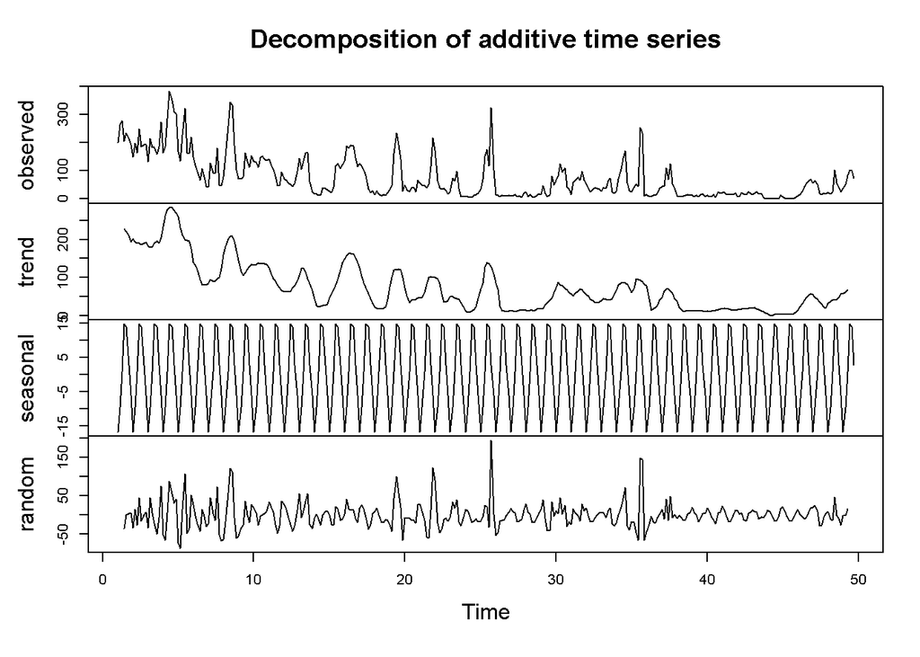

```
##
## #######################
## # KPSS Unit Root Test #
## #######################
##
## Test is of type: mu with 5 lags.
##
## Value of test-statistic is: 0.0104
##
## Critical value for a significance level of:
##                 10pct  5pct 2.5pct  1pct
## critical values 0.347 0.463  0.574 0.739
```

# 6.2.b Decompostion at Frequency=30

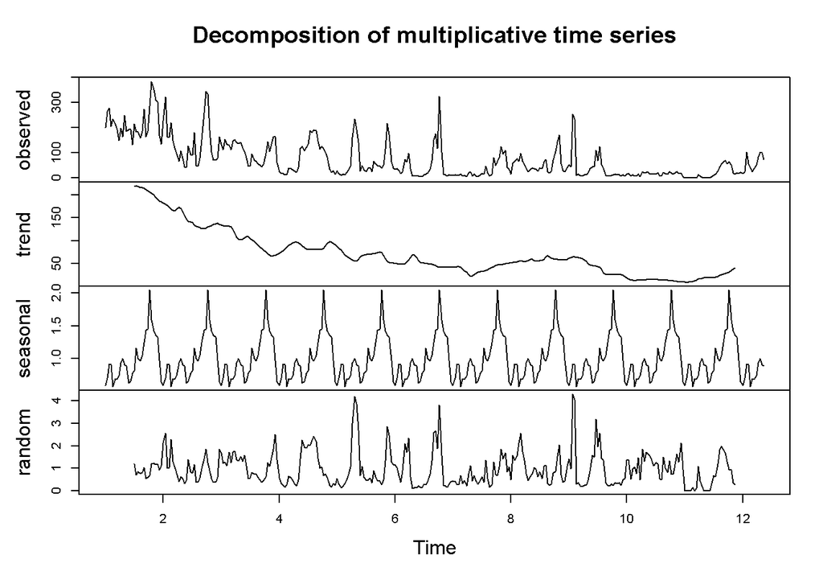

```
##
## #######################
## # KPSS Unit Root Test #
## #######################
##
## Test is of type: mu with 5 lags.
##
## Value of test-statistic is: 0.0814
##
## Critical value for a significance level of:
##                 10pct  5pct 2.5pct  1pct
## critical values 0.347 0.463  0.574 0.739
```

# 6.3 ARIMA Model

We can try p=1 and p=2 since ACF has a sinusoidal pattern and PACF’s significance is decreasing after lag1 and lag2. There is no need for MA parameter.

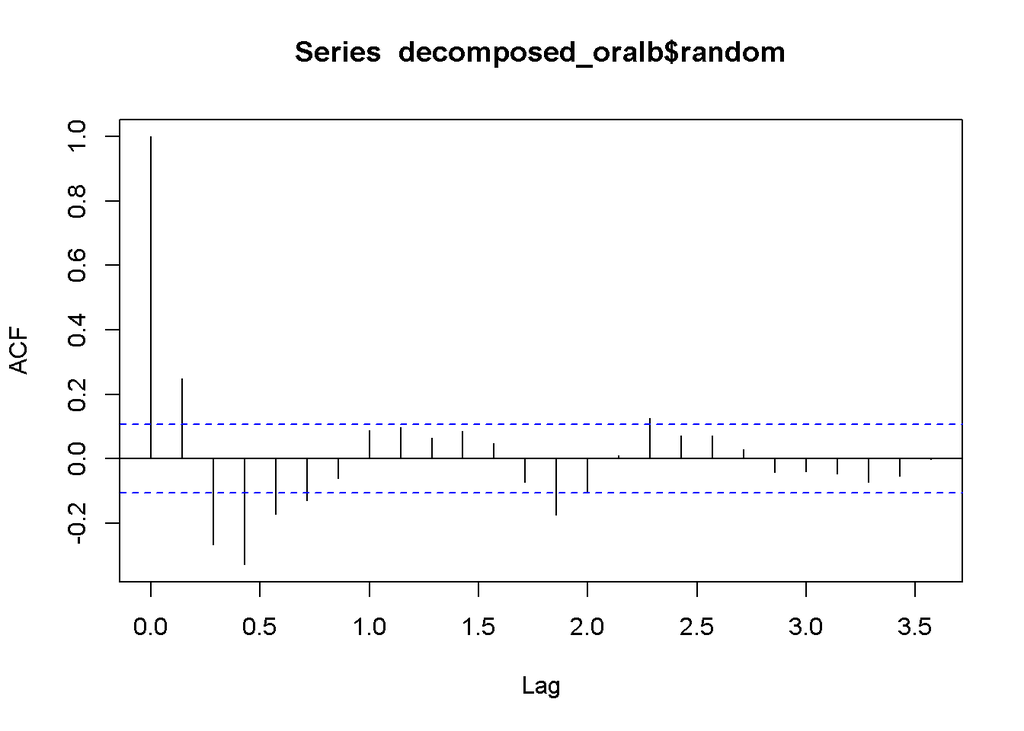

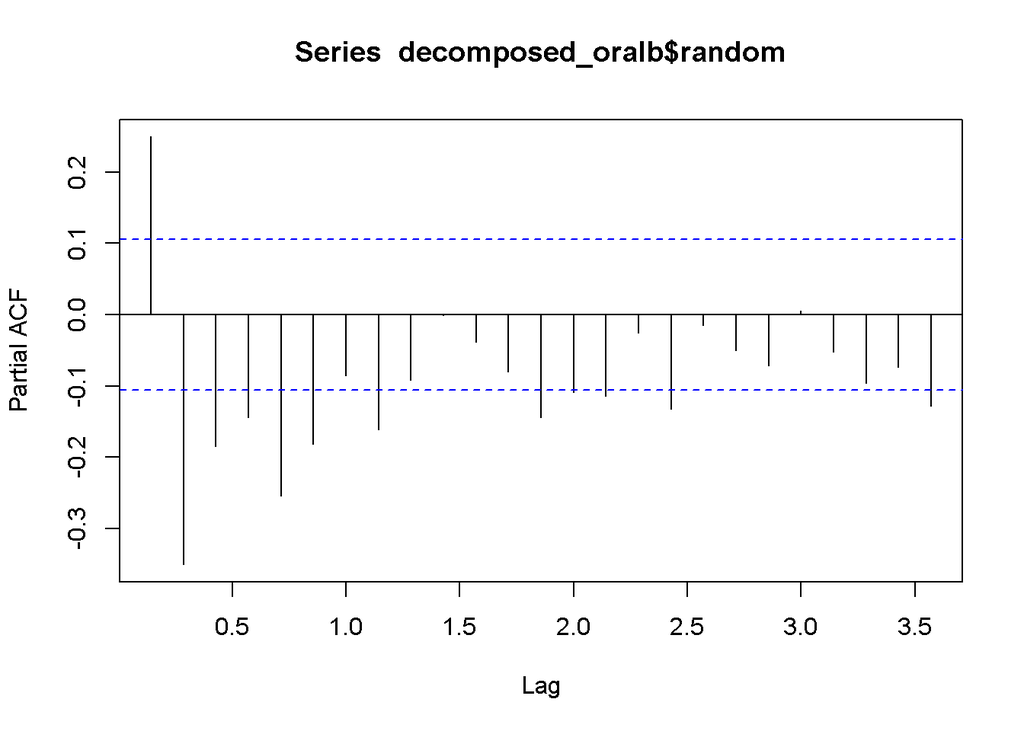

```
##      [,1]               [,2]
## [1,] "model 1"          "model 2"
## [2,] "3303.03875444816" "3260.99565182208"
```

Model 2, which has parameters (2,0,0) is providing a better result sue to its lower AIC.

# 6.4 Regressor Analysis

```
##
## Call:
## lm(formula = sold_count ~ ., data = data_oralb)
##
## Residuals:
##     Min      1Q  Median      3Q     Max
## -92.314  -7.521  -0.362   5.748  80.449
##
## Coefficients:
##                       Estimate Std. Error t value Pr(>|t|)
## (Intercept)         -4.566e+03  1.311e+03  -3.483 0.000568 ***
## price               -5.360e-01  2.215e-01  -2.420 0.016122 *
## event_date           2.505e-01  7.110e-02   3.522 0.000493 ***
## visit_count         -1.563e-02  1.949e-03  -8.020 2.31e-14 ***
## favored_count       -1.800e-02  6.761e-03  -2.662 0.008176 **
## basket_count         2.674e-01  1.041e-02  25.674  < 2e-16 ***
## category_sold        1.719e-02  3.189e-02   0.539 0.590177
## category_brand_sold -1.050e-03  8.405e-04  -1.249 0.212491
## category_visits      3.169e-04  3.117e-02   0.010 0.991896
## ty_visits           -1.134e-07  1.275e-07  -0.889 0.374446
## category_basket      7.787e-04  1.627e-04   4.787 2.65e-06 ***
## category_favored    -4.495e-03  8.574e-04  -5.243 2.97e-07 ***
## w_dayCum             2.452e+00  3.937e+00   0.623 0.533885
## w_dayÇar             1.323e+00  4.109e+00   0.322 0.747746
## w_dayPaz             4.316e+00  3.919e+00   1.101 0.271715
## w_dayPer             2.291e+00  4.026e+00   0.569 0.569754
## w_dayPzt             2.318e+00  3.961e+00   0.585 0.558859
## w_daySal             3.007e+00  4.009e+00   0.750 0.453815
## monthAra            -1.184e+01  1.082e+01  -1.095 0.274566
## monthEki            -1.967e+01  6.999e+00  -2.810 0.005277 **
## monthEyl            -1.270e+01  6.356e+00  -1.997 0.046674 *
## monthHaz             1.102e+01  7.123e+00   1.548 0.122726
## monthKas            -2.228e+01  8.642e+00  -2.578 0.010401 *
## monthMar            -1.806e+01  1.322e+01  -1.366 0.172901
## monthMay             7.410e+00  8.981e+00   0.825 0.409946
## monthNis             1.296e+01  1.471e+01   0.881 0.379095
## monthOca            -1.087e+01  1.218e+01  -0.893 0.372541
## monthŞub            -1.917e+01  1.243e+01  -1.542 0.124175
## monthTem             7.177e+00  5.867e+00   1.223 0.222205
## ---
## Signif. codes:  0 '***' 0.001 '**' 0.01 '*' 0.05 '.' 0.1 ' ' 1
##
## Residual standard error: 18.94 on 304 degrees of freedom
##   (9 observations deleted due to missingness)
## Multiple R-squared:  0.9454, Adjusted R-squared:  0.9404
## F-statistic: 187.9 on 28 and 304 DF,  p-value: < 2.2e-16
```

The most significant input attributes can be seen as visit_count, basket_count,category_basket and category_favored.Now we will plot these attributes with random component to visualize their relation. Basket_count and category_basket is correlated so we will choose only one of them.

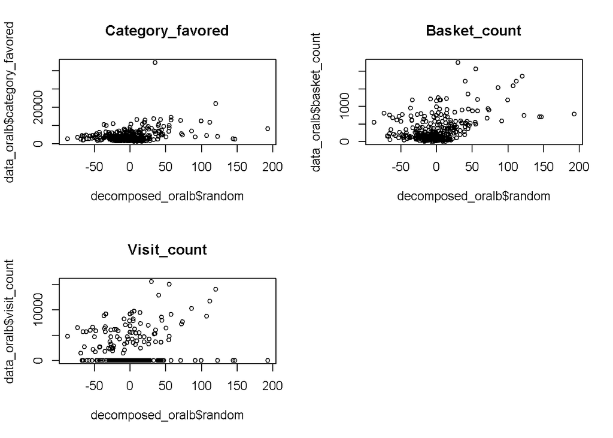

After the visual inspection we decided to go with basket_count and visit_count.

# 6.5 ARIMAX Model

```
##      [,1]               [,2]               [,3]
## [1,] "model 1"          "model 2"          "auto.arima"
## [2,] "3117.83747969969" "3116.85311435892" "3091.63110800713"
```

The models are improved since their AIC values are decreased. Auto.arima function provided a better result and with the (1,1,1)(0,0,1)[7] parameter values.

# 6.6 Performance of the Models

```
##    n     mean       sd        CV     FBias     MAPE     RMSE      MAD     MADP
## 1: 7 56.71429 27.34175 0.4820964 -95.55029 146.7691 10931.68 7485.365 131.9838
##       WMAPE
## 1: 131.9838
```

```
##    n     mean       sd        CV     FBias     MAPE     RMSE      MAD     MADP
## 1: 7 56.71429 27.34175 0.4820964 -100.5675 157.2067 11557.52 8003.559 141.1207
##       WMAPE
## 1: 141.1207
```

```
##    n     mean       sd        CV     FBias     MAPE     RMSE      MAD     MADP
## 1: 7 41.14286 29.99127 0.7289544 -120.3925 264.2166 10214.25 6986.956 169.8218
##       WMAPE
## 1: 169.8218
```

## 7. Model of Facial Cleanser Sales

# 7.1 Visualisation of the Data

We can observe that Facial Cleanser has a frequent demand. Similar to most of the products, during the fall the sales reached to a peak level due to the Black Friday promotions. Also, sales increased during the mid of February as well, which corresponds to Valentine’s day. So we can say that the sales are easily affected by the promotions on the special days. We can say that there is an increasing trend too.

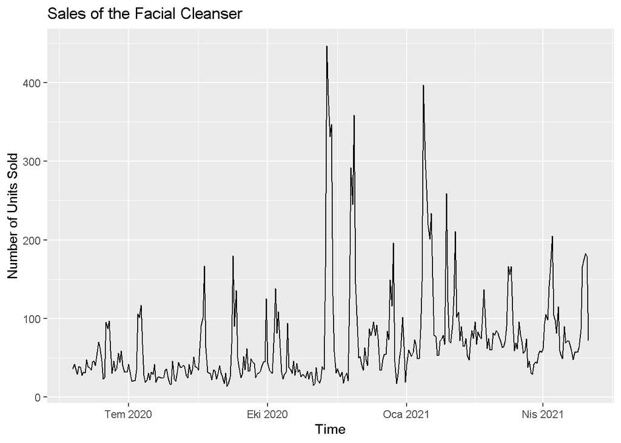

```
##
## #######################
## # KPSS Unit Root Test #
## #######################
##
## Test is of type: mu with 5 lags.
##
## Value of test-statistic is: 1.174
##
## Critical value for a significance level of:
##                 10pct  5pct 2.5pct  1pct
## critical values 0.347 0.463  0.574 0.739
```

The KPSS test shows that the data is not stationary, with its really high test static value.